# Test a Perceptual Phenomenon_FGS

### Analyzing the Stroop Effect

Perform the analysis in the space below. Remember to follow [the instructions](https://docs.google.com/document/d/1-OkpZLjG_kX9J6LIQ5IltsqMzVWjh36QpnP2RYpVdPU/pub?embedded=True) and review the [project rubric](https://review.udacity.com/#!/rubrics/71/view) before submitting. Once you've completed the analysis and write-up, download this file as a PDF or HTML file, upload that PDF/HTML into the workspace here (click on the orange Jupyter icon in the upper left then Upload), then use the Submit Project button at the bottom of this page. This will create a zip file containing both this .ipynb doc and the PDF/HTML doc that will be submitted for your project.

(1) What is the independent variable? What is the dependent variable?

In this experiment each participant takes the test (independent variable) with two conditions. The outcome of each test , the measure as the reaction time (dependent variable).

The below independent variable (the test) is repeated under different conditions:

```
- Congruent : words match displayed colour
- Incongruent : words and colour do not match
```

The Dependant variable , our measure , is the recorded reaction time each participant takes to each condition.

(2) What is an appropriate set of hypotheses for this task? Specify your null and alternative hypotheses, and clearly define any notation used. Justify your choices.

This experiment the same group has repeated the same test, under different conditions.

Based on the sample measurements the Incongruent test has a greater average reaction time then the Congruent condition. In our alternative hypothesisis , the population average reaction time will be smaller under the Congruent condition.

To verify this we take the counter example : the null hypothesis . We assume the same true average reaction time for both conditions. The population difference in average means will be 0.

The significance level, alpha, is set at 0.05. Meaning 5% risk of being wrong in favour of the alternative hypothesis is considered to be satisfactory. In this case we would assume the population average respose time to the Congruent condition to be the lower, when in reality the null hypothesis was in fact true.

To verify if our alternative hypothesis is statistically significant, a the [T-Test on Two related samples](https://docs.scipy.org/doc/scipy/reference/generated/scipy.stats.ttest_rel.html) of scores is the chosen method.

$$H_0: \mu_{Congruent} - \mu_{Incongruent} = 0$$

$$H_1: \mu_{Congruent} - \mu_{Incongruent} < 0$$

$$\alpha = 0.05$$

$$p < 0.05$$

(3) Report some descriptive statistics regarding this dataset. Include at least one measure of central tendency and at least one measure of variability. The name of the data file is 'stroopdata.csv'.

```python
import pandas as pd
```

```python
stroop = pd.read_csv('stroopdata.csv')
stroop.head()
```

|  | Congruent | Incongruent |
| --- | --- | --- |
| 0 | 12.079 | 19.278 |
| 1 | 16.791 | 18.741 |
| 2 | 9.564 | 21.214 |
| 3 | 8.630 | 15.687 |
| 4 | 14.669 | 22.803 |

```python
stroop.shape #verify the dataframe shape
```

```
(24, 2)
```

```python
stroop_stats = stroop.describe()
stroop_IQR = stroop_stats.loc[['25%','75%']] \
                         .copy() \
                         .diff() \
                         .dropna() \
                         .rename(index = {'75%':'IQR'}) #calculated the Inter Quartille Range (IQR)

stroop_stats = stroop_stats.append(stroop_IQR) \
                           .T \
                           .round(2) #appended and rounded to 2 dec. points all results.
stroop_stats
```

|  | count | mean | std | min | 25% | 50% | 75% | max | IQR |
| --- | --- | --- | --- | --- | --- | --- | --- | --- | --- |
| Congruent | 24.0 | 14.05 | 3.56 | 8.63 | 11.90 | 14.36 | 16.20 | 22.33 | 4.31 |
| Incongruent | 24.0 | 22.02 | 4.80 | 15.69 | 18.72 | 21.02 | 24.05 | 35.26 | 5.33 |

The Standard Deviation and Inter Quartile Range is also bigger on the Incongruent condition; 4.8 vs 3.56 and 5.33 vs 4.31.

(4) Provide one or two visualizations that show the distribution of the sample data. Write one or two sentences noting what you observe about the plot or plots.

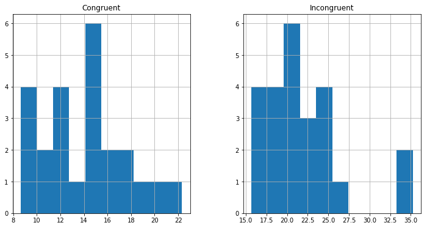

```python
# Build the visualizations here
%matplotlib inline
stroop.hist(figsize=(12,6)); #histogram with sample distribution
```

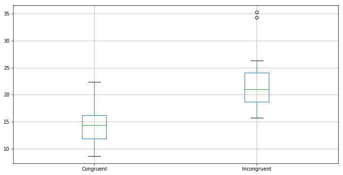

```python
stroop.boxplot(figsize=(12,6));
```

The distribution shape:

```
- Incongruent - right skewed data. Two outliers are present.
- Congruent - more plateau towards a center value no outliers present.
```

Data appears not to be normally distributed for both conditions. Measures appear significantly lower for the Congruent condition.

(5) Now, perform the statistical test and report your results. What is your confidence level or Type I error associated with your test? What is your conclusion regarding the hypotheses you set up? Did the results match up with your expectations? **Hint:** Think about what is being measured on each individual, and what statistic best captures how an individual reacts in each environment.

```python
# Perform the statistical test here
import numpy as np
```

The significance level, alpha, is set at 0.05. There's a 5% risk and not above of Type I error associated with the test; assuming the incongruent condition has a greater or equal average response time when the null hypothesis was in fact true.

I've decided to carry out a confidence interval analysis, using the population mean difference for both conditions.

```python
# first calculate the difference from each sample pair
stroop['difference'] = stroop['Congruent'] - stroop['Incongruent']
stroop.head()
```

|  | Congruent | Incongruent | difference |
| --- | --- | --- | --- |
| 0 | 12.079 | 19.278 | -7.199 |
| 1 | 16.791 | 18.741 | -1.950 |
| 2 | 9.564 | 21.214 | -11.650 |
| 3 | 8.630 | 15.687 | -7.057 |
| 4 | 14.669 | 22.803 | -8.134 |

```python
# assign mean,std and n of the sample difference
sample_diff_mean = stroop['difference'].mean()
sample_diff_std = np.std(stroop['difference'])
n = len(stroop)
sample_diff_mean, sample_diff_std, n
```

```
(-7.964791666666666, 4.762398030222158, 24)
```

The sample means shows a reduction in reaction time of ~ -7.96s with a standard deviation of ~ 4.76s

```python
std_error = sample_diff_std / np.sqrt(n) # assign standard error variable
t_critical = 2.262 # for 9 degrees of freedom t.975 from table http://www.normaltable.com/ttable.html

upper = sample_diff_mean + t_critical * std_error
lower = sample_diff_mean - t_critical * std_error

ci = lower, upper
ci
```

```
(-10.163728072932743, -5.765855260400588)
```

We can be 95% confident our population mean will lie between the above interval values.

Acording to this interval a true mean reduction of 0, i.e. no mean difference in reaction time for both conditions, is not a valid value, with 95% confidence.

Below is the T-test result on two related samples.

```python
from scipy import stats

t_stat, p_value = stats.ttest_rel(stroop['Congruent'].values, stroop['Incongruent'].values)
t_stat, p_value
```

```
(-8.020706944109957, 4.103000585711178e-08)
```

The observed value t values is ~ 8.02. The p-value is the prob, under the null hypothesis, of getting the value we got or something even further to the left in the t-distribution. The p-value is below 0.05. There is significant evidence that the null hypothesis can be rejected.

Conclusion : Both the 95% confidence interval and hypothesis test lend significance that the true mean population difference for both conditions, Congruent and Incongruent is not zero. As I've taken the exact same test, the results match my expectations.

(6) Optional: What do you think is responsible for the effects observed? Can you think of an alternative or similar task that would result in a similar effect? Some research about the problem will be helpful for thinking about these two questions!

Not answered. If possible I would like some guidance from reviewer in this question. My initial research lead me to Multistable perception and optical illusion as similar task that could result in similar effect.

I understand is not compulsory but would like to attemp to resolve it. Also requested help with Udacity community. Thank you for your time.

### References

Books: [Pratical Statistics for Data Scientists](http://shop.oreilly.com/product/0636920048992.do)

Websites:

https://www.isixsigma.com/tools-templates/hypothesis-testing/making-sense-two-sample-t-test/

http://www.normaltable.com/ttable.html

https://docs.scipy.org/doc/scipy/reference/generated/scipy.stats.ttest_rel.html

[An Example of a Paired-Difference t Test and Confidence Interval](https://www.youtube.com/watch?v=upc4zN_-YFM)